# BA_HW6

#### Home Work - 6

Balaji Avvaru

```python
import scipy.sparse
from sklearn.feature_extraction.text import TfidfVectorizer
import pandas as pd
import numpy as np
import seaborn as sn
import matplotlib
import matplotlib.pyplot as plt
```

#### 1. Evaluate text similarity of Amazon book search results by doing the following:

a. Do a book search on Amazon via the search box. Manually copy the full book title (including subtitle) of each of the top 24 books listed in the first two pages of search results.

b. In Python, run one of the text-similarity measures covered in this course, e.g., cosine similarity. Compare each of the book titles, pairwise, to every other one.

c. Which two titles are the most similar to each other? Which are the most dissimilar? Where do they rank, among the first 24 results?

- Searched amazon website with search words "Sprider man book"

```python
book_titles = [
    'The Amazing Spider-Man (Marvel: Spider-Man) (Little Golden Book)',
    'This is Spider-Man Level 1 Reader (World of Reading)',
    'World of Reading Super Hero Adventures: Thwip! You Are It!: Level Pre-1',
    "Marvel Spider-man I'm Ready to Read Sound Book - PI Kids",
    'The Story of Spider-Man (Level 2) (World of Reading)',
    'Marvel - Spider-man Me Reader Electronic Reader and 8 Sound Book Library - PI Kids',
    'Marvel Spider-Man Look and Find Activity Book - PI Kids',
    'Marvel Action: Spider-Man: A New Beginning (Book One)',
    '5-Minute Spider-Man Stories (5-Minute Stories)',
    'Spider-Man: Life Story'
    'Miles Morales: Shock Waves (Original Spider-Man Graphic Novel)',
    'Spider-Man: Maximum Venom: Volume 1 (Marvel Spider-Man) (Screen Comix)',
    'Ultimate Sticker Book: Marvel Spider-Man: Into the Spider-Verse',
    'Marvel Super Heroes Spider-man, Avengers, Guardians, and More! - Me Reader Electronic Reader with 8 Book Library',
    "Marvel's Super Hero Adventures Spider-Man: A Tangled Web (Magnetic Hardcover)",
    'Miles Morales (Marvel Spider-Man) (Little Golden Book)',
    'World of Reading: This is Miles Morales',
    "Marvel Super Hero Adventures Buggin' Out!: An Early Chapter Book (Super Hero Adventures Chapter Books, 3)",
    'Marvel Spider-Man: Miles Morales to the Rescue!: Meet the amazing web-slinger! (DK Readers Level 1)'
    "Spider-Man: No Way Home: Spider-Man's Very Strange Day!",
    'Spider-Man: Into the Spider-Verse -The Art of the Movie',
    'Spiderman Coloring Book For Kids: Lots Of Beautiful Illustrations And Patterns For You To Freely Color And Have More Fun.',
    'Spider-Man: Far From Home: Spider-Man Swings Through Europe!',
    'Marvel Action: Spider-Man: Spider-Chase (Book Two)',
    'Marvel Action: Black Panther: Stormy Weather (Book One)',
    'Amazing Spider-Man: Story of Spider-Man (Level 2), The: The Story of Spider-Man (World of Reading: Level 2)']
```

```python
print(" Number of titles:", len(book_titles))
```

```
 Number of titles: 24
```

```python
# adding stop_words="english" will remove the stop words from the titles.
vect = TfidfVectorizer(min_df=1, stop_words="english")
tfidf = vect.fit_transform(book_titles)
pairwise_similarity = tfidf * tfidf.T

simillarity_array = scipy.sparse.csr_matrix.toarray(pairwise_similarity)
pd.DataFrame.sparse.from_spmatrix(pairwise_similarity)
```

|  | 0 | 1 | 2 | 3 | 4 | 5 | 6 | 7 | 8 | 9 | ... | 14 | 15 | 16 | 17 | 18 | 19 | 20 | 21 | 22 | 23 |
| --- | --- | --- | --- | --- | --- | --- | --- | --- | --- | --- | --- | --- | --- | --- | --- | --- | --- | --- | --- | --- | --- |
| 0 | 1.000000 | 0.167521 | 0.000000 | 0.217663 | 0.162734 | 0.179837 | 0.238844 | 0.257963 | 0.088652 | 0.174471 | ... | 0.702418 | 0.000000 | 0.055549 | 0.318587 | 0.207484 | 0.037221 | 0.233634 | 0.365527 | 0.094970 | 0.372641 |
| 1 | 0.167521 | 1.000000 | 0.408030 | 0.073709 | 0.699739 | 0.387509 | 0.080882 | 0.087357 | 0.055195 | 0.108626 | ... | 0.085879 | 0.426383 | 0.000000 | 0.208711 | 0.129180 | 0.000000 | 0.145461 | 0.145975 | 0.000000 | 0.581259 |
| 2 | 0.000000 | 0.408030 | 1.000000 | 0.000000 | 0.396371 | 0.000000 | 0.000000 | 0.000000 | 0.000000 | 0.000000 | ... | 0.000000 | 0.282420 | 0.417358 | 0.054776 | 0.000000 | 0.000000 | 0.000000 | 0.000000 | 0.000000 | 0.278797 |
| 3 | 0.217663 | 0.073709 | 0.000000 | 1.000000 | 0.071603 | 0.468612 | 0.436378 | 0.165272 | 0.039007 | 0.076767 | ... | 0.162476 | 0.000000 | 0.048883 | 0.111701 | 0.091293 | 0.114289 | 0.102799 | 0.218503 | 0.083574 | 0.113319 |
| 4 | 0.162734 | 0.699739 | 0.396371 | 0.071603 | 1.000000 | 0.059160 | 0.078571 | 0.084860 | 0.053618 | 0.105522 | ... | 0.083425 | 0.414199 | 0.000000 | 0.202747 | 0.125489 | 0.000000 | 0.141305 | 0.141804 | 0.000000 | 0.902539 |
| 5 | 0.179837 | 0.387509 | 0.000000 | 0.468612 | 0.059160 | 1.000000 | 0.360543 | 0.136551 | 0.032228 | 0.063427 | ... | 0.134240 | 0.000000 | 0.040388 | 0.092289 | 0.075428 | 0.094427 | 0.084935 | 0.180531 | 0.069050 | 0.093626 |
| 6 | 0.238844 | 0.080882 | 0.000000 | 0.436378 | 0.078571 | 0.360543 | 1.000000 | 0.181355 | 0.042803 | 0.084238 | ... | 0.178286 | 0.000000 | 0.053640 | 0.122571 | 0.100177 | 0.125410 | 0.112803 | 0.239765 | 0.091706 | 0.124346 |
| 7 | 0.257963 | 0.087357 | 0.000000 | 0.165272 | 0.084860 | 0.136551 | 0.181355 | 1.000000 | 0.046229 | 0.090981 | ... | 0.192558 | 0.000000 | 0.057934 | 0.132382 | 0.108196 | 0.038819 | 0.121833 | 0.477524 | 0.257416 | 0.134299 |
| 8 | 0.088652 | 0.055195 | 0.000000 | 0.039007 | 0.053618 | 0.032228 | 0.042803 | 0.046229 | 1.000000 | 0.057485 | ... | 0.045447 | 0.000000 | 0.000000 | 0.066687 | 0.068362 | 0.000000 | 0.076978 | 0.077250 | 0.000000 | 0.084855 |
| 9 | 0.174471 | 0.108626 | 0.000000 | 0.076767 | 0.105522 | 0.063427 | 0.084238 | 0.090981 | 0.057485 | 1.000000 | ... | 0.191211 | 0.128324 | 0.000000 | 0.181019 | 0.134540 | 0.000000 | 0.151496 | 0.152031 | 0.000000 | 0.166998 |
| 10 | 0.244454 | 0.127821 | 0.000000 | 0.124788 | 0.124168 | 0.103102 | 0.136931 | 0.147892 | 0.067643 | 0.133124 | ... | 0.145390 | 0.000000 | 0.019280 | 0.174068 | 0.158313 | 0.000000 | 0.178266 | 0.224386 | 0.032962 | 0.196508 |
| 11 | 0.305755 | 0.122104 | 0.000000 | 0.182772 | 0.118615 | 0.151010 | 0.200558 | 0.216612 | 0.064618 | 0.127170 | ... | 0.212947 | 0.000000 | 0.053985 | 0.172535 | 0.386744 | 0.036174 | 0.170294 | 0.317263 | 0.092297 | 0.187719 |
| 12 | 0.162013 | 0.349102 | 0.082698 | 0.103799 | 0.053297 | 0.637847 | 0.113900 | 0.123017 | 0.029034 | 0.057140 | ... | 0.120936 | 0.000000 | 0.135130 | 0.083143 | 0.067953 | 0.024380 | 0.076517 | 0.162638 | 0.062207 | 0.084347 |
| 13 | 0.142974 | 0.064438 | 0.326029 | 0.080279 | 0.062597 | 0.066328 | 0.088091 | 0.095142 | 0.034101 | 0.067111 | ... | 0.093533 | 0.000000 | 0.408730 | 0.182092 | 0.079810 | 0.000000 | 0.089869 | 0.136052 | 0.033234 | 0.099065 |
| 14 | 0.702418 | 0.085879 | 0.000000 | 0.162476 | 0.083425 | 0.134240 | 0.178286 | 0.192558 | 0.045447 | 0.191211 | ... | 1.000000 | 0.441991 | 0.056954 | 0.301592 | 0.106366 | 0.038163 | 0.119771 | 0.254577 | 0.097371 | 0.132027 |
| 15 | 0.000000 | 0.426383 | 0.282420 | 0.000000 | 0.414199 | 0.000000 | 0.000000 | 0.000000 | 0.000000 | 0.128324 | ... | 0.441991 | 1.000000 | 0.000000 | 0.216185 | 0.000000 | 0.000000 | 0.000000 | 0.000000 | 0.000000 | 0.218503 |
| 16 | 0.055549 | 0.000000 | 0.417358 | 0.048883 | 0.000000 | 0.040388 | 0.053640 | 0.057934 | 0.000000 | 0.000000 | ... | 0.056954 | 0.000000 | 1.000000 | 0.012671 | 0.000000 | 0.018328 | 0.000000 | 0.064539 | 0.046764 | 0.000000 |
| 17 | 0.318587 | 0.208711 | 0.054776 | 0.111701 | 0.202747 | 0.092289 | 0.122571 | 0.132382 | 0.066687 | 0.181019 | ... | 0.301592 | 0.216185 | 0.012671 | 1.000000 | 0.156075 | 0.000000 | 0.271054 | 0.206265 | 0.021664 | 0.336208 |
| 18 | 0.207484 | 0.129180 | 0.000000 | 0.091293 | 0.125489 | 0.075428 | 0.100177 | 0.108196 | 0.068362 | 0.134540 | ... | 0.106366 | 0.000000 | 0.000000 | 0.156075 | 1.000000 | 0.000000 | 0.180162 | 0.200887 | 0.000000 | 0.198598 |
| 19 | 0.037221 | 0.000000 | 0.000000 | 0.114289 | 0.000000 | 0.094427 | 0.125410 | 0.038819 | 0.000000 | 0.000000 | ... | 0.038163 | 0.000000 | 0.018328 | 0.000000 | 0.000000 | 1.000000 | 0.000000 | 0.043245 | 0.031335 | 0.000000 |
| 20 | 0.233634 | 0.145461 | 0.000000 | 0.102799 | 0.141305 | 0.084935 | 0.112803 | 0.121833 | 0.076978 | 0.151496 | ... | 0.119771 | 0.000000 | 0.000000 | 0.271054 | 0.180162 | 0.000000 | 1.000000 | 0.203585 | 0.000000 | 0.223628 |
| 21 | 0.365527 | 0.145975 | 0.000000 | 0.218503 | 0.141804 | 0.180531 | 0.239765 | 0.477524 | 0.077250 | 0.152031 | ... | 0.254577 | 0.000000 | 0.064539 | 0.206265 | 0.200887 | 0.043245 | 0.203585 | 1.000000 | 0.286766 | 0.224417 |
| 22 | 0.094970 | 0.000000 | 0.000000 | 0.083574 | 0.000000 | 0.069050 | 0.091706 | 0.257416 | 0.000000 | 0.000000 | ... | 0.097371 | 0.000000 | 0.046764 | 0.021664 | 0.000000 | 0.031335 | 0.000000 | 0.286766 | 1.000000 | 0.000000 |
| 23 | 0.372641 | 0.581259 | 0.278797 | 0.113319 | 0.902539 | 0.093626 | 0.124346 | 0.134299 | 0.084855 | 0.166998 | ... | 0.132027 | 0.218503 | 0.000000 | 0.336208 | 0.198598 | 0.000000 | 0.223628 | 0.224417 | 0.000000 | 1.000000 |

24 rows × 24 columns

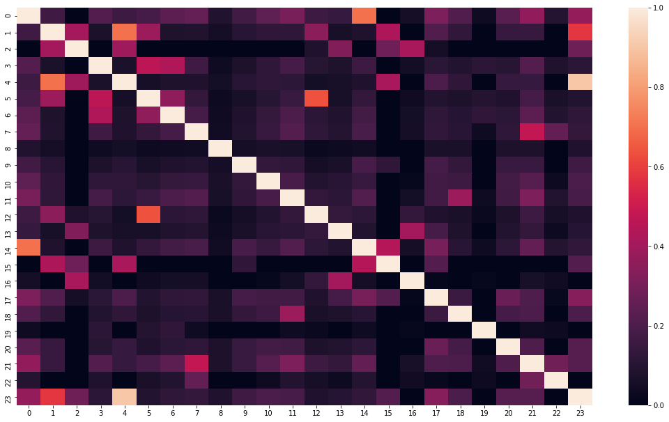

```python
pair_df = pd.DataFrame(simillarity_array)
fig = matplotlib.pyplot.gcf()
fig.set_size_inches(18.5, 10.5, forward=True)
sn.heatmap(pair_df)
plt.show()
```

```python
most_similar = []
most_dissimilar = []
for idx, i in enumerate(simillarity_array):

    list_init = []
    list_idx = []
    for j in i:
        list_init.append(j)

    list_sort = list_init[:]
    list_sort.sort()
    maxVal = list_sort[-2]
    minVal = list_sort[0]
    maxidx = list_init.index(maxVal)
    minidx = list_init.index(minVal)
    most_similar.append([idx,maxidx,maxVal])
    most_dissimilar.append([idx,minidx,minVal])
```

```python
print("Most similar titles with similarity score:")
print("------------------------------------------")
max_score = 0
first_idx = 0
second_idx = 0
for comb in most_similar:
    if max_score < comb[2]:
        max_score = comb[2]
        first_idx = comb[0]
        second_idx = comb[1]

print(f"  First title (Indexed at {first_idx}): {book_titles[first_idx]}")
print(f"  Second title (Indexed at {second_idx}): {book_titles[second_idx]}")
print("  Similarity Score:", max_score)

print("\nThere are many dissimilar titles with similarity score of ZERO, below are dissimilar titles")
print("  -------------------------------------------------------------------------------------------")

for comb in most_dissimilar:
    print('\n')
    print(f"  First title (Indexed at {comb[0]}): {book_titles[comb[0]]}")
    print(f"  Second title (Indexed at {comb[1]}): {book_titles[comb[1]]}")
    print("  Similarity Score:", comb[2])
```

```
Most similar titles with similarity score:
------------------------------------------
  First title (Indexed at 4): The Story of Spider-Man (Level 2) (World of Reading)
  Second title (Indexed at 23): Amazing Spider-Man: Story of Spider-Man (Level 2), The: The Story of Spider-Man (World of Reading: Level 2)
  Similarity Score: 0.9025386852263086

There are many dissimilar titles with similarity score of ZERO, below are dissimilar titles
  -------------------------------------------------------------------------------------------


  First title (Indexed at 0): The Amazing Spider-Man (Marvel: Spider-Man) (Little Golden Book)
  Second title (Indexed at 2): World of Reading Super Hero Adventures: Thwip! You Are It!: Level Pre-1
  Similarity Score: 0.0


  First title (Indexed at 1): This is Spider-Man Level 1 Reader (World of Reading)
  Second title (Indexed at 16): Marvel Super Hero Adventures Buggin' Out!: An Early Chapter Book (Super Hero Adventures Chapter Books, 3)
  Similarity Score: 0.0


  First title (Indexed at 2): World of Reading Super Hero Adventures: Thwip! You Are It!: Level Pre-1
  Second title (Indexed at 0): The Amazing Spider-Man (Marvel: Spider-Man) (Little Golden Book)
  Similarity Score: 0.0


  First title (Indexed at 3): Marvel Spider-man I'm Ready to Read Sound Book - PI Kids
  Second title (Indexed at 2): World of Reading Super Hero Adventures: Thwip! You Are It!: Level Pre-1
  Similarity Score: 0.0


  First title (Indexed at 4): The Story of Spider-Man (Level 2) (World of Reading)
  Second title (Indexed at 16): Marvel Super Hero Adventures Buggin' Out!: An Early Chapter Book (Super Hero Adventures Chapter Books, 3)
  Similarity Score: 0.0


  First title (Indexed at 5): Marvel - Spider-man Me Reader Electronic Reader and 8 Sound Book Library - PI Kids
  Second title (Indexed at 2): World of Reading Super Hero Adventures: Thwip! You Are It!: Level Pre-1
  Similarity Score: 0.0


```

[output cut: 73 more lines]

```


  First title (Indexed at 21): Marvel Action: Spider-Man: Spider-Chase (Book Two)
  Second title (Indexed at 2): World of Reading Super Hero Adventures: Thwip! You Are It!: Level Pre-1
  Similarity Score: 0.0


  First title (Indexed at 22): Marvel Action: Black Panther: Stormy Weather (Book One)
  Second title (Indexed at 1): This is Spider-Man Level 1 Reader (World of Reading)
  Similarity Score: 0.0


  First title (Indexed at 23): Amazing Spider-Man: Story of Spider-Man (Level 2), The: The Story of Spider-Man (World of Reading: Level 2)
  Second title (Indexed at 16): Marvel Super Hero Adventures Buggin' Out!: An Early Chapter Book (Super Hero Adventures Chapter Books, 3)
  Similarity Score: 0.0
```

#### 2. Now evaluate using a major search engine.

a. Enter one of the book titles from question 1a into Google, Bing, or Yahoo!. Copy the capsule of the first organic result and the 20th organic result. Take web results only (i.e., not video results), and skip sponsored results.

b. Run the same text similarity calculation that you used for question 1b on each of these capsules in comparison to the original query (book title).

c. Which one has the highest similarity measure?

```python
first_title = 'This is Spider-Man Level 1 Reader (World of Reading)'
goggle_first_capsule = 'This is Spider-Man Level 1 Reader (World of Reading)'
goggle_twentieth_capsule = 'This is Spider-Man (Level 1 Reader) - Dayton Metro Library'
```

```python
google_capsules = [first_title, goggle_first_capsule, goggle_twentieth_capsule]
```

```python
# adding stop_words="english" will remove the stop words from the titles.
vect = TfidfVectorizer(min_df=1, stop_words="english")
tfidf = vect.fit_transform(google_capsules)
pairwise_similarity = tfidf * tfidf.T

simillarity_array = scipy.sparse.csr_matrix.toarray(pairwise_similarity)
pd.DataFrame.sparse.from_spmatrix(pairwise_similarity)
```

|  | 0 | 1 | 2 |
| --- | --- | --- | --- |
| 0 | 1.000000 | 1.000000 | 0.416607 |
| 1 | 1.000000 | 1.000000 | 0.416607 |
| 2 | 0.416607 | 0.416607 | 1.000000 |

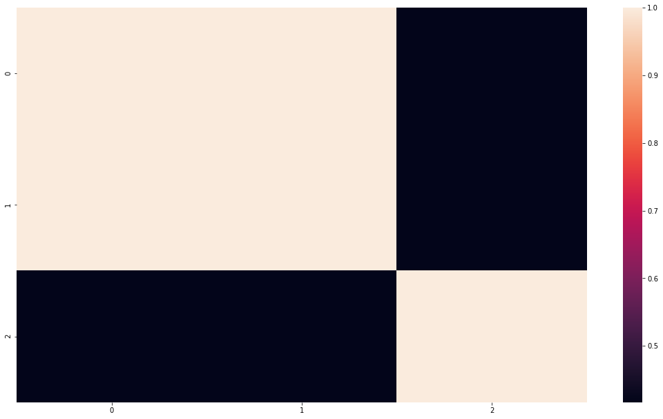

```python
pair_df = pd.DataFrame(simillarity_array)
fig = matplotlib.pyplot.gcf()
fig.set_size_inches(18.5, 10.5, forward=True)
sn.heatmap(pair_df)
plt.show()
```

In my Google results, it makes sense that the 1st result would be a relatively high similarity score (in my example, it is displaying same book that Amazon is displaying), while the 20th would be virtually less similar. Obviously, Google wants to present the most relevant results first, and then less similar books.